# Exploratory Analysis of Fine Particulate Pollutants

2024-08-23

## Fine Particulate Matter (PM2.5) Emissions

PM2.5 is an ambient air pollutant for which there is strong evidence that it’s harmful to human health. In the United States, the Environmental Protection Agency (EPA) is tasked with tracking the emissions of this pollutant into the atmosphere. Approximately every 3 years, the EPA releases its database on emissions of PM2.5. This database is known as the National Emissions Inventory (NEI).

For each year and for each type of particulate matter source, the NEI records how many tons of PM2.5 were emitted from that source over the course of the entire year. This data set contains emission data for the years 1999, 2002, 2005, and 2008. For this project, we analyzed emission data for the US, Baltimore, MD, and Los Angeles (LA), California.

## PM2.5 Emissions in US

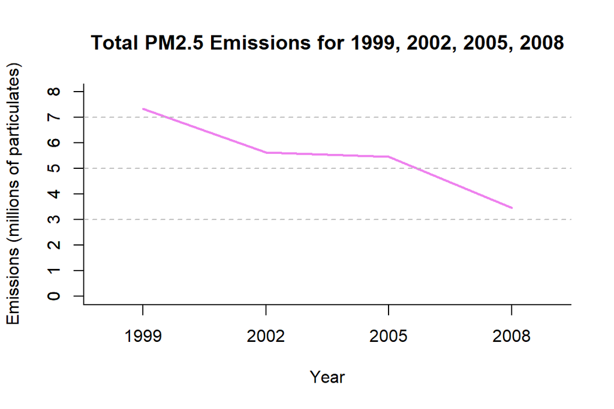

## PM2.5 Emissions in Baltimore

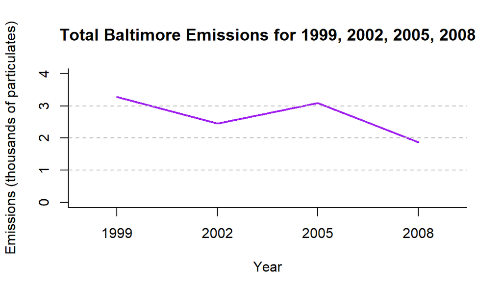

Total PM2.5 emissions also decreased in Baltimore between 1999 and 2008, but there was a dramatic increase between 2002 and 2005.

## Sources of Emissions in Baltimore

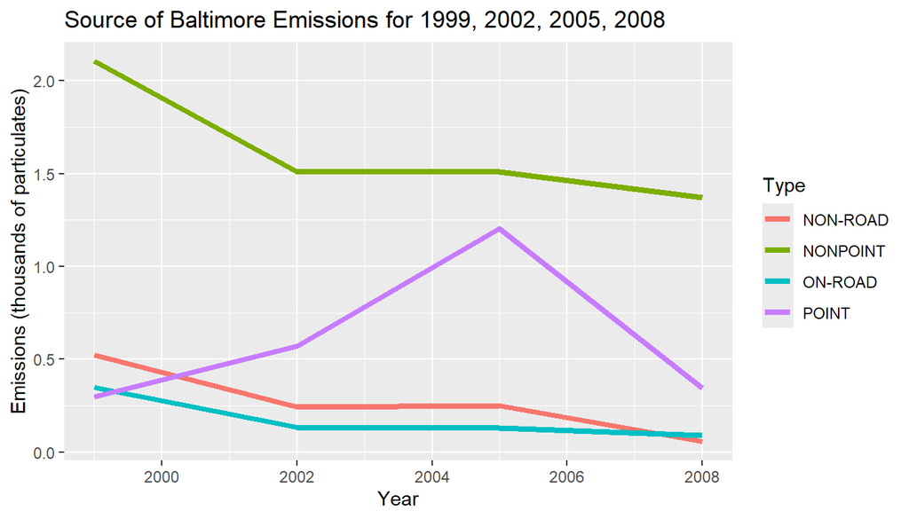

Although `nonpoint` sources of emissions have decreased in Baltimore, it was still the largest source of PM2.5 particulates between 1999 and 2008.

## Emissions from Coal Combustion

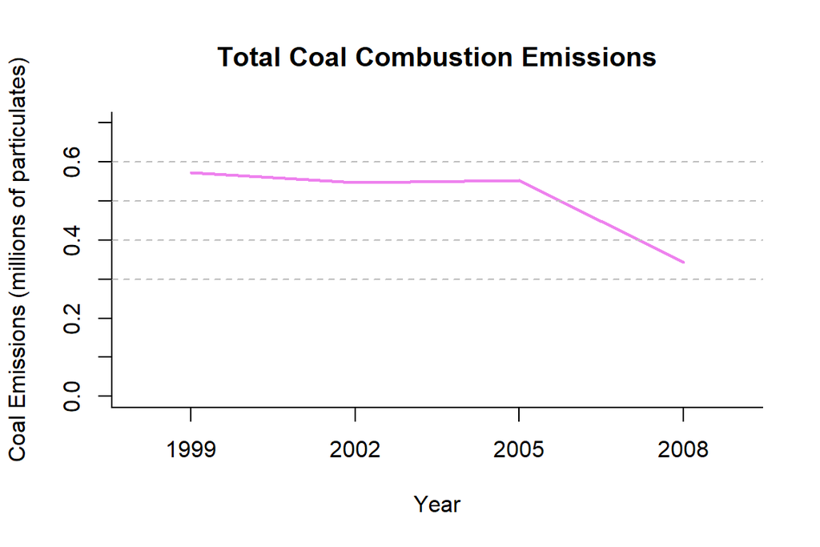

Between 1999 and 2005, emissions from coal combustion remained steady, but after 2005 there was a significant drop in emissions.

## Motor Vehicle Emissions in Baltimore

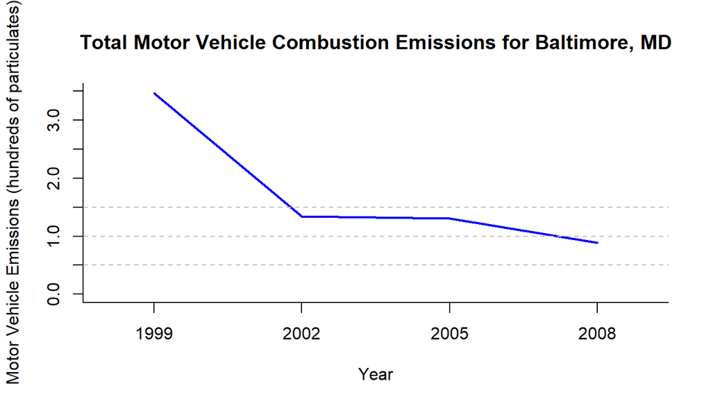

Motor vehicle emissions in Baltimore decreased significantly between 1999 and 2005, but the drop after 2005 was much less.

## Motor Vehicle Emissions in Baltimore and LA

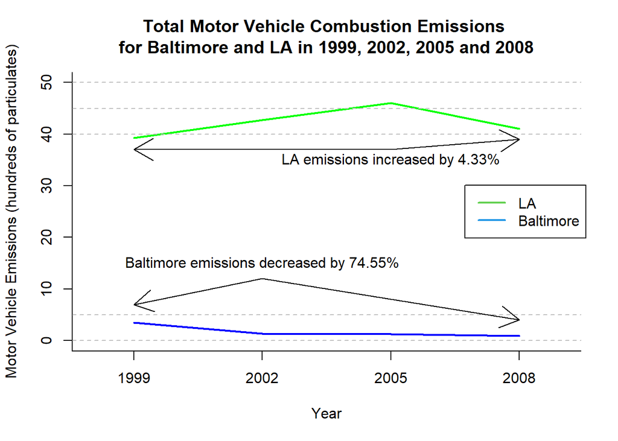

## Source of Data Set

The data for this project can be found at this link:

https://d396qusza40orc.cloudfront.net/exdata%2Fdata%2FNEI_data.zip